# Assingment5

# k-Fold Cross Validation

k-fold cv is used to guage how well a model performs. One way to reduce both the bias and variance is by using k-fold cross validation. It has a train()function. We are using the train() function with 10-fold cross validation to pick a decision tree.

```r
library(caret)
set.seed(123)
folds<-createFolds(y=Bank_train$y..category, k=10, list=TRUE, returnTrain=FALSE)

#Checking the number of observations in each fold
sapply(folds, length)
```

```
## Fold01 Fold02 Fold03 Fold04 Fold05 Fold06 Fold07 Fold08 Fold09 Fold10
##    316    317    317    316    317    316    317    316    317    316
```

```r
cvCtrl <- trainControl(method="cv", number=10)
set.seed(123)
Bank.caret.10folds<-train(y..category ~., data=Bank_train, method="rpart", metric="Accuracy", tuneLength=10, trControl=cvCtrl) #Here I am using "Accuracy" as the measure to choose among multiple possible models.
#tuneLength decides how many models to test. Her I am specifying 10 models.
Bank.caret.10folds
```

```
## CART
##
## 3165 samples
##   10 predictor
##    2 classes: 'no', 'yes'
##
## No pre-processing
## Resampling: Cross-Validated (10 fold)
## Summary of sample sizes: 2849, 2848, 2848, 2849, 2848, 2849, ...
## Resampling results across tuning parameters:
##
##   cp           Accuracy   Kappa
##   0.001302083  0.8875075  0.4048255
##   0.001736111  0.8881384  0.4026267
##   0.003038194  0.8951024  0.4128115
##   0.005208333  0.8928932  0.3952252
##   0.006510417  0.8944725  0.4077418
##   0.007812500  0.8909965  0.3782589
##   0.009114583  0.8935211  0.3852618
##   0.010416667  0.8935201  0.3770857
##   0.031250000  0.8928912  0.3716280
##   0.050347222  0.8811963  0.2940501
##
## Accuracy was used to select the optimal model using  the largest value.
## The final value used for the model was cp = 0.003038194.
```

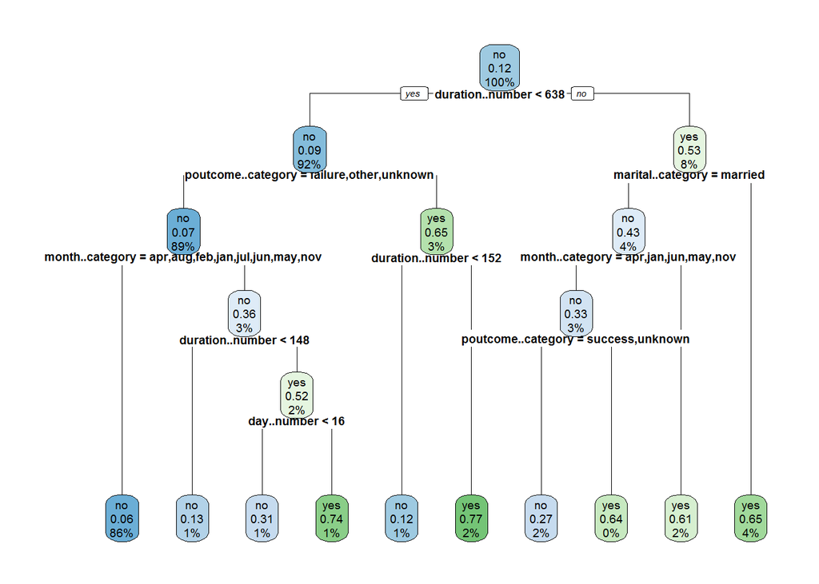

```r
#It gives a tree with Accuracy = 89.51% and complexity parameter = 0.003038194.
#Since the chosen cp=0.003038194, we will use this to prune our decision tree.

Bank.rpart.pruned<-prune(Bank.rpart, cp=0.003038194)
rpart.plot(Bank.rpart.pruned, cex = 0.6)
```

```r
#Now let's apply our pruned tree to predict the test (hold out) set.

actual <- Bank_test$y..category
Bank_predicted.10fold <- predict(Bank.rpart.pruned, newdata=Bank_test, type="class")
Bank_results.matrix.10fold <- confusionMatrix(Bank_predicted.10fold, actual, positive="yes")
print(Bank_results.matrix.10fold)
```

```
## Confusion Matrix and Statistics
##
##           Reference
## Prediction   no  yes
##        no  1167   78
##        yes   52   59
##
##                Accuracy : 0.9041
##                  95% CI : (0.8872, 0.9193)
##     No Information Rate : 0.899
##     P-Value [Acc > NIR] : 0.28170
##
##                   Kappa : 0.4237
##  Mcnemar's Test P-Value : 0.02833
##
##             Sensitivity : 0.43066
##             Specificity : 0.95734
##          Pos Pred Value : 0.53153
##          Neg Pred Value : 0.93735
##              Prevalence : 0.10103
##          Detection Rate : 0.04351
##    Detection Prevalence : 0.08186
##       Balanced Accuracy : 0.69400
##
##        'Positive' Class : yes
##
```

```r
# Accuracy = 90.41%
# Sensitivity = 43.06%
# Specificity = 95.73%

#Compare it to the Accuracy of the previous model
print(Bank_results.matrix)
```

```
## Confusion Matrix and Statistics
##
##           Reference
## Prediction   no  yes
##        no  1167   78
##        yes   52   59
##
##                Accuracy : 0.9041
##                  95% CI : (0.8872, 0.9193)
##     No Information Rate : 0.899
##     P-Value [Acc > NIR] : 0.28170
##
##                   Kappa : 0.4237
##  Mcnemar's Test P-Value : 0.02833
##
##             Sensitivity : 0.43066
##             Specificity : 0.95734
##          Pos Pred Value : 0.53153
##          Neg Pred Value : 0.93735
##              Prevalence : 0.10103
##          Detection Rate : 0.04351
##    Detection Prevalence : 0.08186
##       Balanced Accuracy : 0.69400
##
##        'Positive' Class : yes
##
```

```r
# 1. Accuracy of the Model after pruning and tesing with Test dataset - 90.41% ( Which is almost the same as before pruning)
```

# Bootstrapping (Resampling Technique) to choose the CP value to prune the tree

By doing Resampling we are guaging model performance. Here we resample a new data to test. Boostrapping model creates a decision tree to check error rate and repeats until it averages error rate out.

```r
cvCtrl <- trainControl(method="boot", number=10) #10 resampling iterations as before.
set.seed(123)
Bank.caret.bootstrap<-train(y..category ~., data=Bank_train, method="rpart", metric="Accuracy", tuneLength=10, trControl=cvCtrl)
Bank.caret.bootstrap
```

```
## CART
##
## 3165 samples
##   10 predictor
##    2 classes: 'no', 'yes'
##
## No pre-processing
## Resampling: Bootstrapped (10 reps)
## Summary of sample sizes: 3165, 3165, 3165, 3165, 3165, 3165, ...
## Resampling results across tuning parameters:
##
##   cp           Accuracy   Kappa
##   0.001302083  0.8762906  0.3719634
##   0.001736111  0.8784169  0.3754140
##   0.003038194  0.8844398  0.3836089
##   0.005208333  0.8882821  0.3918222
##   0.006510417  0.8899039  0.3977387
##   0.007812500  0.8908532  0.3882300
##   0.009114583  0.8918007  0.3898116
##   0.010416667  0.8926627  0.3861448
##   0.031250000  0.8912953  0.3862059
##   0.050347222  0.8795526  0.2281991
##
## Accuracy was used to select the optimal model using  the largest value.
## The final value used for the model was cp = 0.01041667.
```

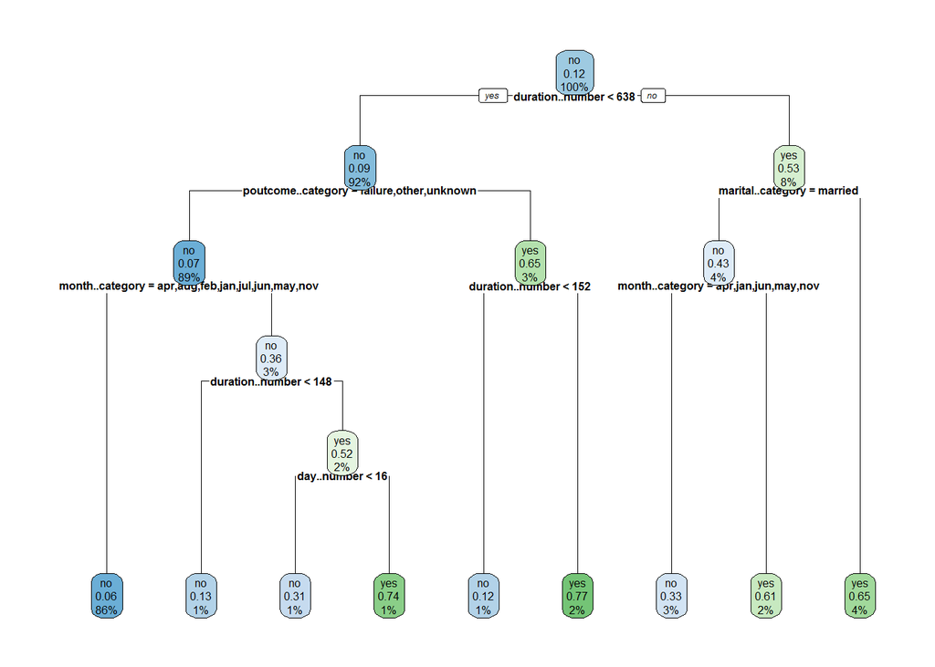

```r
# Accuracy = 89.26%
#Since the chosen cp=0.01041667, we will use this to prune our decision tree.

Bank.rpart.pruned.boot<-prune(Bank.rpart, cp=0.01041667)
rpart.plot(Bank.rpart.pruned.boot,cex = 0.5)
```

```r
#Now let's apply our pruned tree to predict the test (hold out) set.
#Compare

actual <- Bank_test$y..category
Bank_predicted.boot <- predict(Bank.rpart.pruned.boot, newdata=Bank_test, type="class")
Bank_results.matrix.boot <- confusionMatrix(Bank_predicted.boot, actual, positive="yes")
print(Bank_results.matrix.boot)
```

```
## Confusion Matrix and Statistics
##
##           Reference
## Prediction   no  yes
##        no  1170   81
##        yes   49   56
##
##                Accuracy : 0.9041
##                  95% CI : (0.8872, 0.9193)
##     No Information Rate : 0.899
##     P-Value [Acc > NIR] : 0.28170
##
##                   Kappa : 0.4112
##  Mcnemar's Test P-Value : 0.00655
##
##             Sensitivity : 0.40876
##             Specificity : 0.95980
##          Pos Pred Value : 0.53333
##          Neg Pred Value : 0.93525
##              Prevalence : 0.10103
##          Detection Rate : 0.04130
##    Detection Prevalence : 0.07743
##       Balanced Accuracy : 0.68428
##
##        'Positive' Class : yes
##
```

```r
# Accuracy = 90.41%
# Sensitivity = 40.87%
# Specificity = 95.98%

print(Bank_results.matrix.10fold) #compare to the original tree. What do you see?
```

```
## Confusion Matrix and Statistics
##
##           Reference
## Prediction   no  yes
##        no  1167   78
##        yes   52   59
##
##                Accuracy : 0.9041
##                  95% CI : (0.8872, 0.9193)
##     No Information Rate : 0.899
##     P-Value [Acc > NIR] : 0.28170
##
##                   Kappa : 0.4237
##  Mcnemar's Test P-Value : 0.02833
##
##             Sensitivity : 0.43066
##             Specificity : 0.95734
##          Pos Pred Value : 0.53153
##          Neg Pred Value : 0.93735
##              Prevalence : 0.10103
##          Detection Rate : 0.04351
##    Detection Prevalence : 0.08186
##       Balanced Accuracy : 0.69400
##
##        'Positive' Class : yes
##
```

```r
# Accuracy of the Model after pruning and tesing with Test dataset - 90.41%, Not a significant increase in the Accuracy.
```